# Clean 5 - Maps and summary tables

TG

2024-01-11

```r
library(lubridate)
library(ggplot2)
library(stringr)
library(rfishbase)
library(Hmisc)
library(vegan)
library(mobr)
library(viridis)
library(plotrix)
library(sjmisc)
library(sf)
library(ggspatial)
library(dplyr)
library(tidyr)
library(leaflet)
library(rmapshaper)
library(patchwork)


dir <- "G:\\My Drive\\PHD\\chapter 3 MPA dd\\Meddata-DD\\final plots and models\\maps"
```

# In this script:

1. Mediterranean Sea map
2. Map for the 3 case studies
3. Summary statistics that appear in the manuscript

# Input files:

loaded from the `clean output data` folder

- `Clean_medata_dd.Rdata` - dark diversity calculation for MeData
- `unique_coords` - dataframe with distinct survey locations

# Outputs files:

Maps are saved in the `maps` folder

- `combined_map` - plot of all maps

Tables are saved at directory folder

*`Transects table`- the number of transects conducted on each site (Appendix 7)

*`Basin table` - the number of transects and sites in each Mediterranean Sea basin (Appendix 8)

```r
select <- dplyr::select

load("G:\\My Drive\\PHD\\chapter 3 MPA dd\\Meddata-DD\\clean output data\\unique_coords_lis.Rdata")

load("G:\\My Drive\\PHD\\chapter 3 MPA dd\\Meddata-DD\\clean output data\\Clean_MeData_dd_lis.Rdata")
```

# Part 1 - Maps

## load study site map

```r
med_seas <- st_read("Med_World_Seas_IHO_v3_MarineRegions/Medit_seas_IHO.shp")
```

### Banyuls

crop only the area of Banyuls MPA

```r
banyus_cropped <- st_crop(med_seas, xmin = 3.1, xmax = 3.18,
                                    ymin = 42.46, ymax = 42.53)
banyus<-unique_coords %>% filter(country=="France")
```

### Medes

crop only the area of Medes MPA

```r
Medes<-unique_coords %>% filter(new_site_name=="medes")

Medes_cropped <- st_crop(med_seas, xmin = 3.169, xmax = 3.26,
                                    ymin = 42.03, ymax = 42.11)
```

### Brijoni

crop only the area of Brijoni MPA

```r
brijuni<-unique_coords %>% filter(new_site_name=="brijuni")

brijuni_cropped <- st_crop(med_seas, xmin = 13.7, xmax = 13.85,
                                    ymin = 44.83, ymax = 44.95)
```

## Plot Mediterranean Sea map

```
## Scale on map varies by more than 10%, scale bar may be inaccurate
```

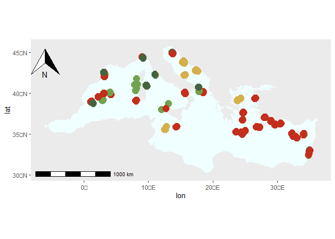

```r
Med_map <- ggplot(unique_coords) +
  geom_sf(data = med_seas$geometry, mapping = aes(),fill= "azure",color = NA) +
  geom_point(data =unique_coords,aes(x = lon, y = lat, color = enforcement,size = 1),position=position_jitter(h=0.06, w=0.06)) +
  annotation_scale(location = "bl", width_hint = 0.4) +
  annotation_north_arrow(location = "tl", which_north = "true",
        pad_x = unit(0.0, "in"), pad_y = unit(0.2, "in"))+
  theme(legend.position = "none",
        panel.grid.major = element_line(colour = "transparent"))+
        scale_color_manual("Protection level",values=c("#C42E1C","#D4B04A","#70A34E","#446441"))

Med_map
```

## Plots of case studies

find the center lat and lon for plotting porpuse

```r
b_bounds<-st_bbox(banyus_cropped$geometry)
c_bounds<-st_bbox(Medes_cropped$geometry)
d_bounds<-st_bbox(brijuni_cropped$geometry)

b_central_lat <- (b_bounds[[4]] + b_bounds[[2]]) / 2
b_central_lon <- (b_bounds[[3]] + b_bounds[[1]]) / 2

c_central_lat <- (c_bounds[[4]] + c_bounds[[2]]) / 2
c_central_lon <- (c_bounds[[3]] + c_bounds[[1]]) / 2

d_central_lat <- (d_bounds[[4]] + d_bounds[[2]]) / 2
d_central_lon <- (d_bounds[[3]] + d_bounds[[1]]) / 2
```

plot the case-sutdy sites

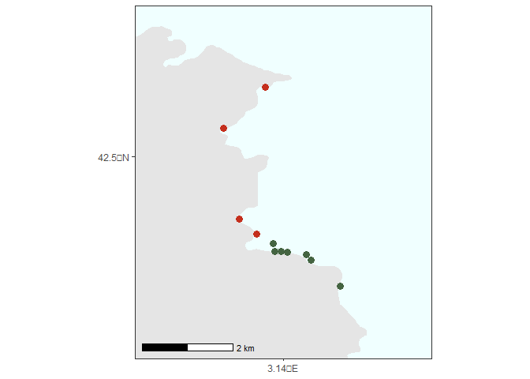

```r
banyus<-ggplot() +
  geom_sf(data = banyus_cropped,fill= "azure",color = NA)+
  geom_point(data =banyus,aes(x = lon, y = lat, color = enforcement),size = 3)+
  theme_bw()+
  theme(panel.background = element_rect(fill = "grey90",color = "black"),
       legend.position = "none",axis.title =  element_blank(),
        panel.grid.major = element_line(colour = "transparent"))+
        scale_color_manual("Protection level",values=c("#C42E1C","#446441"))+
  annotation_scale(location = "bl", width_hint = 0.4)+
    scale_x_continuous(expand = c(0, 0), breaks = round(b_central_lon,2)) +
  scale_y_continuous(expand = c(0, 0), breaks = round(b_central_lat,2))

banyus
```

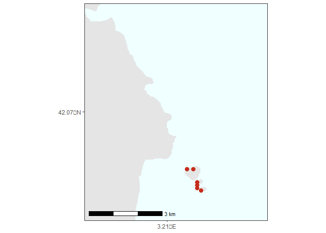

```r
Medes <-ggplot() +
  geom_sf(data = Medes_cropped,fill= "azure",color = NA)+
  geom_point(data =Medes,aes(x = lon, y = lat, color = enforcement),size = 3)+
  theme_bw()+
  theme(panel.background = element_rect(fill = "grey90",color = "black"),
        legend.position = "none",axis.title =  element_blank(),
        panel.grid.major = element_line(colour = "transparent"))+
        scale_color_manual("Protection level",values=c("#C42E1C","#446441"))+
  annotation_scale(location = "bl", width_hint = 0.4)+
      scale_x_continuous(expand = c(0, 0), breaks = round(c_central_lon,2)) +
  scale_y_continuous(expand = c(0, 0), breaks = round(c_central_lat,2))

Medes
```

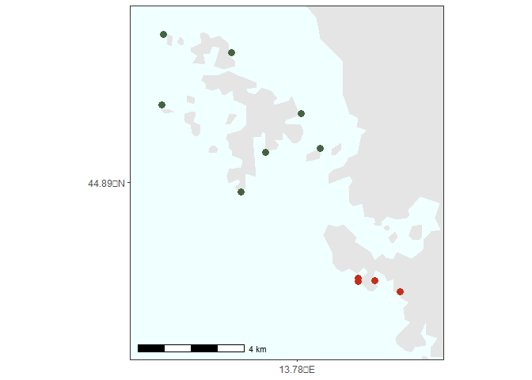

```r
brijuni<-ggplot() +
  geom_sf(data = brijuni_cropped,fill= "azure",color = NA)+
  geom_point(data =brijuni,aes(x = lon, y = lat, color = enforcement),size =3)+
  theme_bw()+
  theme(panel.background = element_rect(fill = "grey90",color = "black"),
       legend.position = "none",
       axis.title =  element_blank(),
        panel.grid.major = element_line(colour = "transparent"))+
        scale_color_manual("Protection level",values=c("#C42E1C","#446441"))+
  annotation_scale(location = "bl", width_hint = 0.4)+
      scale_x_continuous(expand = c(0, 0), breaks = round(d_central_lon,2)) +
  scale_y_continuous(expand = c(0, 0), breaks = round(d_central_lat,2))

brijuni
```

## Plot all Maps and save

```
## Scale on map varies by more than 10%, scale bar may be inaccurate
```

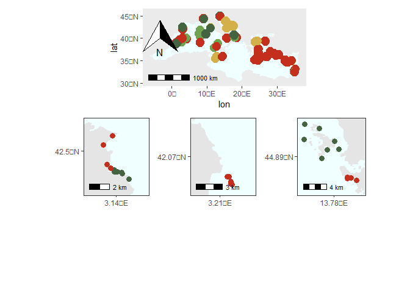

```r
combined_map <- Med_map / (banyus + Medes + brijuni) +
  plot_layout(ncol = 1,nrow = 3,widths = c(14,7,7,7))

# Print the combined plot

combined_map
```

```r
#ggsave(combined_map,filename = "combined_map.pdf",path = dir , width=10, height=10)
```

# Part 2 - tables and summary statistics

```r
rm(list=setdiff(ls(), "dd_data"))

dir<- "G:\\My Drive\\PHD\\chapter 3 MPA dd\\Meddata-DD\\final plots and models\\transect tables"
```

# Transect table

```r
dd_data$Site <- sub("_", " ", dd_data$Site)
dd_data$Site<-str_to_title(dd_data$Site)
```

```r
Transects_table <- dd_data %>%
  group_by(country,Site,Basin,protection,enforcement) %>%
  summarise("Transect number" = n(),
            "Mean observed richness" = round(mean(observed_richness),1),
            "Mean dark diversity" = round(mean(dark),1))
```

```
## You can override using the `.groups` argument.
```

```r
Transects_table$country<-as.character(Transects_table$country)

Transects_table<-Transects_table %>% arrange(country,Site,protection,enforcement)

Transects_table$enforcement[Transects_table$enforcement==0]<-"Not protected"
Transects_table$enforcement[Transects_table$enforcement==1]<-"Minimally protected"
Transects_table$enforcement[Transects_table$enforcement==2]<-"Partly protected"
Transects_table$enforcement[Transects_table$enforcement==3]<-"Fully protected"



# write.csv(Transects_table,paste0(dir,"\\Transects_table.csv"))
```

## Basin table

```r
Basin_table <- dd_data %>%
  group_by(Basin) %>%
  summarise("Number of sites"= n_distinct(Site,protection),
            "Number of transects" = n_distinct(unique_trans_id)) %>%
  arrange(Basin)


#write.csv(Basin_table,paste0(dir,"\\Basin_table.csv"))
```

## Descriptive stats used in the manuscript

- Overall transects conducted - 2249
- Overall transects in fully protected area - 351
- Overall transects in partly protected area - 469
- Overall transects in minimally protected area - 465
- Overall transects in not protected area - 964
- max sampling effort per site - 114
- min sampling effort per site - 4
- number of protected sites - 28
- number of unprotected sites - 33